# Лабораторная работа №6

Реализация основных моделей в подходе сетей Петри

Софич Андрей Геннадьевич

safich05@mail.ru

Российский университет дружбы народов

2026-01-05

## Докладчик

- Софич Андрей Геннадьевич

# Актуальность

## Актуальность

Изучить и применить метод сетей Петри модели SIR

# Цель

## Цели и задачи

Изучить и проанализировать реализацию сетей петри на базовой модели SIR

# Выполнение лабораторной работы

## Выполнение лабораторной работы

Создаем рабочий каталог и инициализируем проект в julia .

[figure not shown]

Инициализация проекта

Создаем файл, где прописываем пакеты, необходимые для выполнения работы и запускаем его.

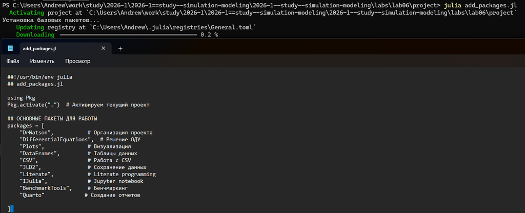

Подключение необходимых пакетов

Создаем файл в папке scr, в котором мы пропишем основную вычислительную логику модели (детерминированная и стохастическая симуляции, вспомогательные функции и визуализация)

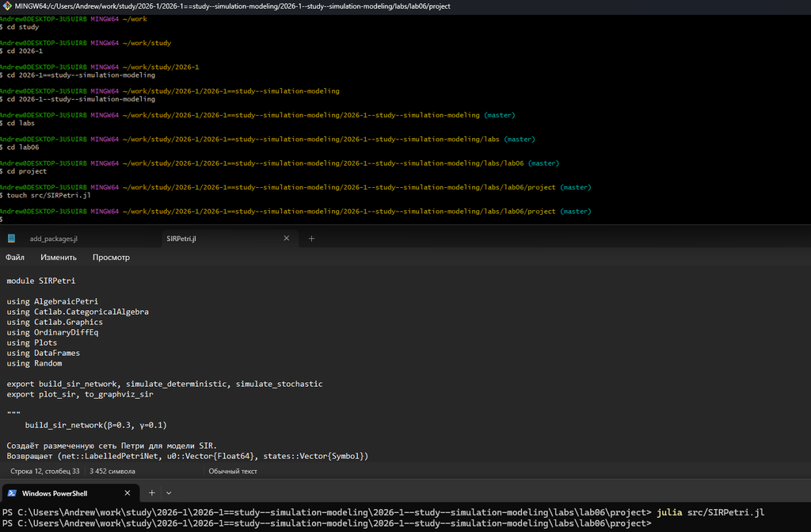

Создание файла для логики модели

Создаем и запускаем скрипт,который проводит базовый прогон модели, задаем основные параметры (бетта, гамма, tmax), зерно для генерации случайных чисел (для стохастической симуляции)

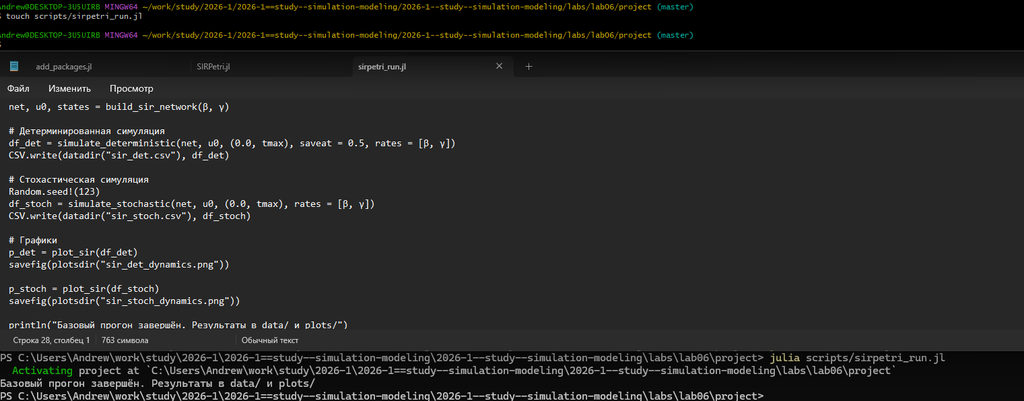

Базовый прогон модели

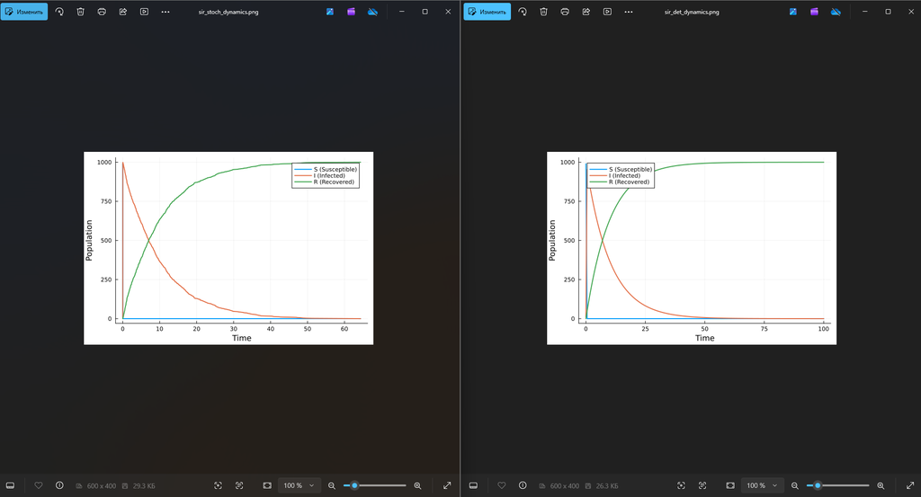

Графики первого прогона модели

Так же мы получили две таблицы с тремя колонками S I R и подробными числами для обеих симуляций

[figure not shown]

Подробные таблицы прогона

Преобразовываем код в произвольные стили и открываем один из них, чтобы убедиться в правильности компиляции

[figure not shown]

Код в стиле jupyter notebook

Создаем файл, в котором будем исследовать коэффициент заражения бета. Пропишем диапазон переменной бета и запустим детерминированную симуляцию. Для каждого прогона вычисляются максимальное число ифицированных (peak_I) и конечно число выздоровевших final_R

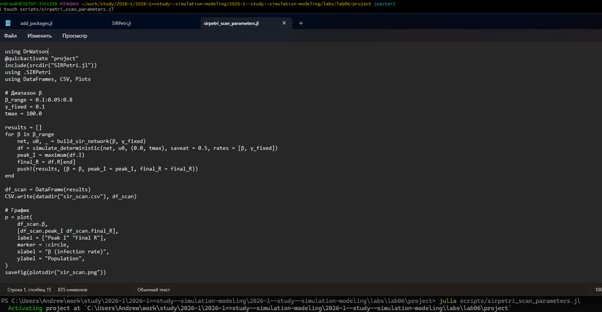

Создание, заполнение и запуск файла

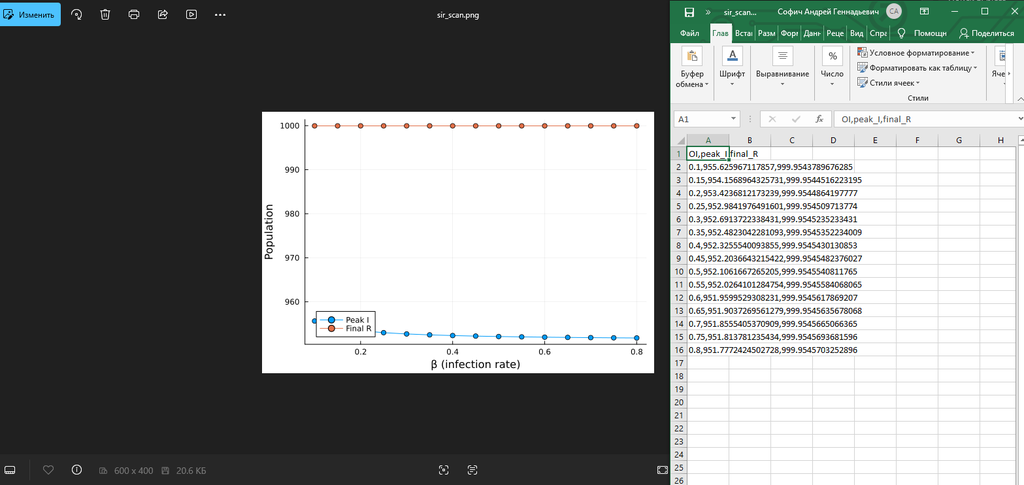

Результаты запуска детерминированной симуляции

Преобразовываем код в произвольные стили, открываем jupyter файл и убеждаемся в правильной компиляции.

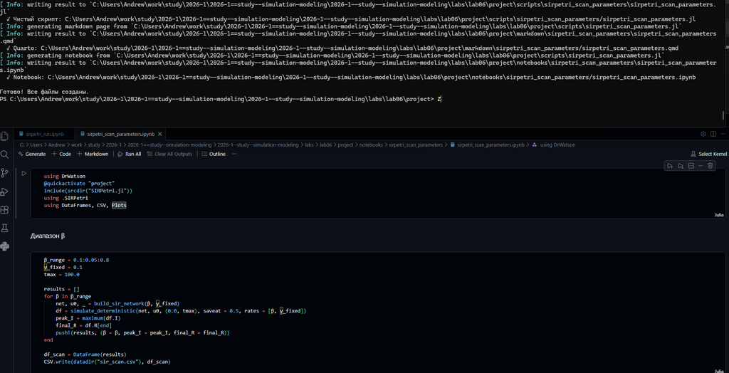

Код из jupyter notebook

Создаем код на основе детерминированной симуляции и делаем gif-анимацию для наглядного анализа распространения эпидемии, его пик и спад

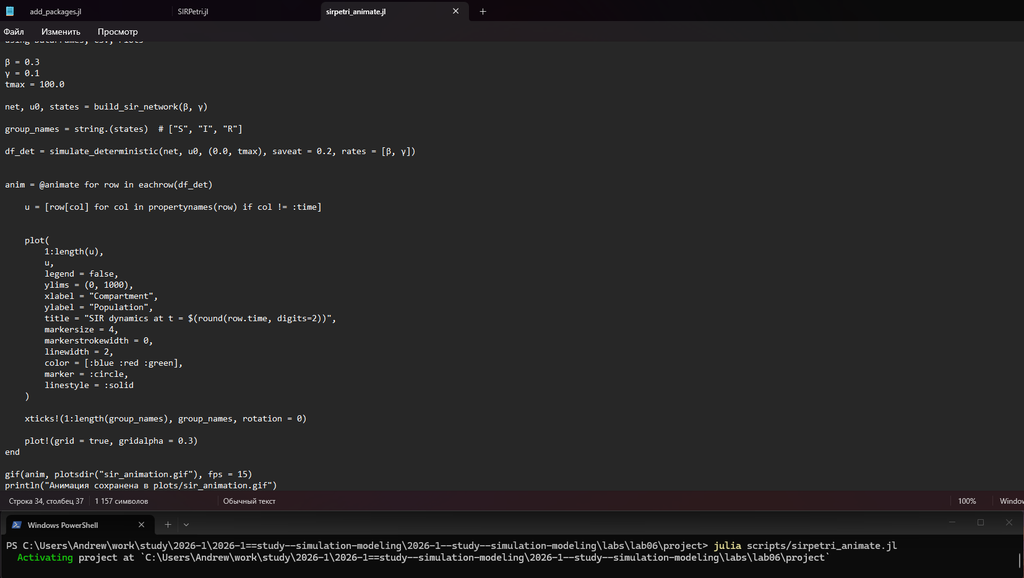

Создание файла с анимацией

Просматриваем результаты анимации, наглядно видно, как на первых кадрах I растет, S падает. В момент пика I достигает максимума, затем снижается, а R растет.

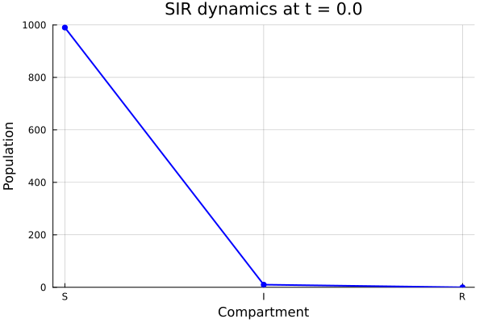

Рисунок 1: Результат анимации

**Ссылки на анимацию на платформах**

**https://rutube.ru/video/3f489af0209fa80963ca823e20d07ba6/**

**https://vkvideo.ru/video-236492644_456239038**

Создаем итоговый отчет, который загружает свсе сохраненные результаты и строит сравнительные графики. Сравнение стохастической и детерминиррованной динамик, а также зависимости пика I от бета

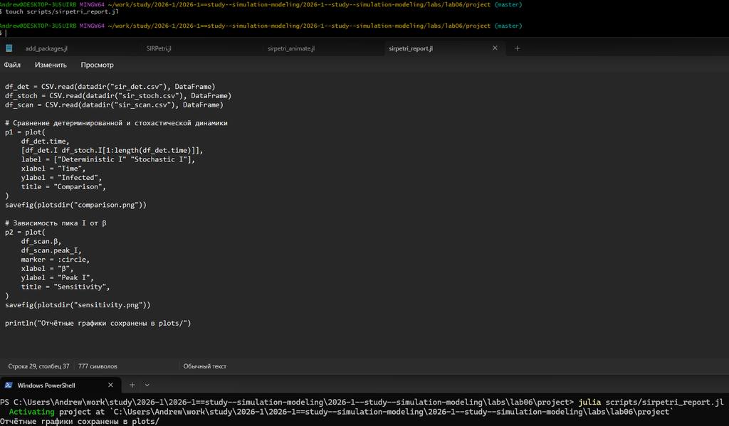

Создание итогового отчета

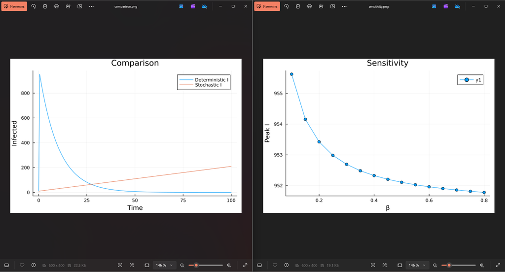

Графики итогового отчета

Преобразовываем код в произвольные стили, открываем jupyter файл и убеждаемся в правильной компиляции.

[figure not shown]

Код из jupyter notebook

# Выводы

## Выводы

В данной работе мы изучили и применили сеть Петри на основе модели SIR